# UC00183_“Data-Driven_Climate_Resilience_for_Melbourne_Integrating_Sensors_Canopy_Coverage_and_Population_Growth (1)

UC00183_“Data-Driven_Climate_Resilience_for_Melbourne_Integrating_Sensors_Canopy_Coverage_and_Population_Growth”

**Authored by:** Harshith Maddila

**Duration:** 120 mins  
**Level:** Intermediate  
**Pre-requisite Skills:** Python, Pandas, GeoPandas, Data Visualisation

## Scenario

Melbourne faces increasing environmental stress due to climate change, urban heat islands, and rapid population growth. Tree canopies are known to help mitigate extreme temperatures and air pollution, but their impact across different zones in Melbourne is not evenly distributed. This project integrates real-time microclimate sensor data, urban greening spatial datasets (tree canopy coverage), and long-term population growth forecasts to analyse and visualise climate vulnerability. It aims to guide city planners in prioritising areas for green infrastructure interventions and sustainable development.

## User Story

As a city planner or environmental analyst, I want to identify areas in Melbourne that are prone to heat stress and poor air quality, especially in high-growth zones, so that I can prioritise green infrastructure initiatives and recommend tree planting or cooling interventions in the most vulnerable regions.

## What This Use Case Will Teach You

- How to preprocess and integrate climate sensor, tree canopy, and population growth datasets.
- Performing exploratory data analysis (EDA) with visualisations to detect trends and spatial patterns.
- Building regression models to assess the effect of canopy proximity on air temperature and pollution (PM2.5, PM10).
- Using forecasting (Prophet) to project future climate stressors such as PM2.5, PM10, and air temperature.
- Developing a Heat Vulnerability Index (HVI) that combines environmental and demographic factors.
- Classifying areas into Low / Medium / High vulnerability to guide resilience planning.

## Introduction

Urban sustainability in cities like Melbourne is challenged by rising temperatures, uneven green cover, and population pressures. This project analyses how urban greening (tree canopies) contributes to cooling and air quality improvement, using real sensor readings and spatial data. The analysis not only detects current vulnerable zones but also overlays future population projections to guide long-term resilience strategies.

## Datasets

Three key datasets are used in this project:

- **Microclimate Sensor Dataset**
  - Includes temperature, humidity, wind, PM2.5, PM10, and location with timestamps
  - Used for time-series analysis and heat/pollution hotspot detection
- **Tree Canopy Dataset (2021)**
  - GeoJSON-style spatial polygon data representing canopy-covered areas
  - Used to calculate canopy density and proximity to sensor points
- **Population Forecasts Dataset (2020–2040)**
  - Population projections by age, gender, and Melbourne suburbs
  - Used to identify future high-growth areas potentially at climate risk

## Project Goals

This project aims to provide a data-driven foundation for urban sustainability and environmental planning by addressing the following goals:

1. **Assess the Impact of Tree Canopies:** Quantify how tree canopy coverage influences temperature and air quality (PM2.5, PM10).
2. **Identify Vulnerable Zones:** Detect heat and pollution hotspots through clustering, and evaluate their exposure relative to tree cover and forecasted population growth.
3. **Forecast Growth-Driven Climate Risk:** Overlay population projections to highlight future high-risk areas where urban heat stress may intensify without intervention.
4. **Create a Heat Vulnerability Index (HVI):** Develop a composite index based on temperature, air quality, tree cover, and demographic exposure to guide prioritisation.
5. **Support Greening Strategy Decisions:** Generate actionable insights and visualisations for urban planners to allocate greening efforts effectively and equitably.

## Importing Packages

```python
!pip install contextily
!pip install prophet
```

```python
import requests
from io import StringIO
import pandas as pd
import matplotlib.pyplot as plt
import seaborn as sns
from tqdm.auto import tqdm
```

## Importing Datasets

```python
def download_dataset(api_key, dataset_id, base_url='https://data.melbourne.vic.gov.au/api/explore/v2.1/catalog/datasets/'):
    format = 'csv'
    url = f'{base_url}{dataset_id}/exports/{format}'
    params = {
        'select': '*',
        'limit': -1,
        'lang': 'en',
        'timezone': 'UTC',
        'api_key': api_key
    }

    with requests.get(url, params=params, stream=True) as response:
        if response.status_code == 200:
            total_size = int(response.headers.get('content-length', 0))
            chunk_size = 1024
            progress_bar = tqdm(total=total_size, unit='iB', unit_scale=True, desc=f"Downloading {dataset_id}")

            content = bytearray()
            for chunk in response.iter_content(chunk_size=chunk_size):
                if chunk:
                    content.extend(chunk)
                    progress_bar.update(len(chunk))

            progress_bar.close()
            data = pd.read_csv(StringIO(content.decode('utf-8')), delimiter=';')
            return data
        else:
            print(f'Request failed with status code {response.status_code}')
            return None

# Dataset IDs
dataset_ids = ['microclimate-sensors-data','tree-canopies-2021-urban-forest','city-of-melbourne-population-forecasts-by-small-area-2020-2040']

# Initialize dictionary to hold the datasets
datasets = {}

# Download each dataset with a progress bar
for dataset_id in dataset_ids:
    datasets[dataset_id] = download_dataset('', dataset_id)
    if datasets[dataset_id] is not None:
        print(f"{dataset_id} downloaded successfully.")

# Convert datasets to DataFrames
climate_sensor_df = datasets['microclimate-sensors-data']#dataset 1
canopy_df = datasets['tree-canopies-2021-urban-forest']#dataset 2
population_df= datasets['city-of-melbourne-population-forecasts-by-small-area-2020-2040'] #dataset 3
```

```
Downloading microclimate-sensors-data: 0.00iB [00:00, ?iB/s]
```

```
microclimate-sensors-data downloaded successfully.
```

```
Downloading tree-canopies-2021-urban-forest: 0.00iB [00:00, ?iB/s]
```

```
tree-canopies-2021-urban-forest downloaded successfully.
```

```
Downloading city-of-melbourne-population-forecasts-by-small-area-2020-2040: 0.00iB [00:00, ?iB/s]
```

```
city-of-melbourne-population-forecasts-by-small-area-2020-2040 downloaded successfully.
```

```python
# Displaying first 5 rows of the climate-sensor dataset
climate_sensor_df.head()
```

|  | device_id | received_at | sensorlocation | latlong | minimumwinddirection | averagewinddirection | maximumwinddirection | minimumwindspeed | averagewindspeed | gustwindspeed | airtemperature | relativehumidity | atmosphericpressure | pm25 | pm10 | noise |
| --- | --- | --- | --- | --- | --- | --- | --- | --- | --- | --- | --- | --- | --- | --- | --- | --- |
| 0 | ICTMicroclimate-03 | 2025-08-17T15:10:39+00:00 | CH1 rooftop | -37.8140348, 144.96728 | 169.0 | 183.0 | 193.0 | 1.5 | 1.7 | 2.2 | 9.1 | 71.8 | 1018.9 | 1.0 | 3.0 | 74.7 |
| 1 | ICTMicroclimate-08 | 2025-08-17T14:31:30+00:00 | Swanston St - Tram Stop 13 adjacent Federation... | -37.8184515, 144.9678474 | 0.0 | 0.0 | 347.0 | 0.0 | 0.0 | 1.2 | 8.8 | 68.8 | 1024.7 | 2.0 | 2.0 | 60.1 |
| 2 | ICTMicroclimate-07 | 2025-08-17T14:25:48+00:00 | Tram Stop 7C - Melbourne Tennis Centre Precinc... | -37.8222341, 144.9829409 | 0.0 | 0.0 | 351.0 | 0.0 | 0.0 | 0.7 | 8.0 | 72.2 | 1026.9 | 1.0 | 1.0 | 57.0 |
| 3 | ICTMicroclimate-02 | 2025-08-17T14:32:01+00:00 | 101 Collins St L11 Rooftop | -37.814604, 144.9702991 | 0.0 | 56.0 | 150.0 | 0.0 | 0.3 | 0.7 | 9.9 | 69.5 | 1019.3 | 1.0 | 3.0 | 68.6 |
| 4 | ICTMicroclimate-08 | 2025-08-17T14:46:32+00:00 | Swanston St - Tram Stop 13 adjacent Federation... | -37.8184515, 144.9678474 | 0.0 | 144.0 | 179.0 | 0.0 | 0.5 | 1.0 | 8.7 | 68.8 | 1024.9 | 2.0 | 2.0 | 59.8 |

```python
#Summary statistics for numeric columns in the climate dataset.
climate_sensor_df.describe()
```

|  | minimumwinddirection | averagewinddirection | maximumwinddirection | minimumwindspeed | averagewindspeed | gustwindspeed | airtemperature | relativehumidity | atmosphericpressure | pm25 | pm10 | noise |
| --- | --- | --- | --- | --- | --- | --- | --- | --- | --- | --- | --- | --- |
| count | 406213.000000 | 451367.000000 | 406055.000000 | 406055.000000 | 451367.000000 | 406055.000000 | 451367.000000 | 451367.000000 | 451367.000000 | 431245.000000 | 431245.000000 | 431245.000000 |
| mean | 20.879110 | 168.145595 | 304.420918 | 4.194003 | 1.057951 | 3.408843 | 15.774036 | 67.220798 | 1003.951140 | 18.146353 | 8.082315 | 66.528574 |
| std | 58.751427 | 126.530234 | 91.229977 | 35.987277 | 0.982617 | 2.596751 | 5.982294 | 17.990467 | 101.093608 | 110.163598 | 12.181031 | 12.794592 |
| min | 0.000000 | 0.000000 | 0.000000 | 0.000000 | 0.000000 | 0.000000 | -0.800000 | 4.000000 | 20.900000 | 0.000000 | 0.000000 | 0.000000 |
| 25% | 0.000000 | 43.000000 | 308.000000 | 0.000000 | 0.400000 | 1.500000 | 11.600000 | 56.100000 | 1009.000000 | 1.000000 | 3.000000 | 59.000000 |
| 50% | 0.000000 | 160.000000 | 353.000000 | 0.000000 | 0.800000 | 2.700000 | 15.100000 | 68.900000 | 1014.900000 | 3.000000 | 5.000000 | 68.300000 |
| 75% | 0.000000 | 307.000000 | 358.000000 | 0.100000 | 1.500000 | 4.800000 | 19.200000 | 80.000000 | 1020.500000 | 7.000000 | 9.000000 | 72.400000 |
| max | 359.000000 | 359.000000 | 360.000000 | 359.000000 | 11.100000 | 52.500000 | 40.800000 | 99.800003 | 1042.900000 | 1030.700000 | 308.000000 | 131.100000 |

```python
#  Quick summary of the DataFrame structure
climate_sensor_df.info()
```

```
<class 'pandas.core.frame.DataFrame'>
RangeIndex: 451892 entries, 0 to 451891
Data columns (total 16 columns):
 #   Column                Non-Null Count   Dtype
---  ------                --------------   -----
 0   device_id             451892 non-null  object
 1   received_at           451892 non-null  object
 2   sensorlocation        445749 non-null  object
 3   latlong               440409 non-null  object
 4   minimumwinddirection  406213 non-null  float64
 5   averagewinddirection  451367 non-null  float64
 6   maximumwinddirection  406055 non-null  float64
 7   minimumwindspeed      406055 non-null  float64
 8   averagewindspeed      451367 non-null  float64
 9   gustwindspeed         406055 non-null  float64
 10  airtemperature        451367 non-null  float64
 11  relativehumidity      451367 non-null  float64
 12  atmosphericpressure   451367 non-null  float64
 13  pm25                  431245 non-null  float64
 14  pm10                  431245 non-null  float64
 15  noise                 431245 non-null  float64
dtypes: float64(12), object(4)
memory usage: 55.2+ MB
```

```python
# Displaying first 5 rows of tree canopy dataset
canopy_df.head()
```

|  | geo_point_2d | geo_shape |
| --- | --- | --- |
| 0 | -37.77506304683423, 144.93898465421296 | {"coordinates": [[[[144.9389624164712, -37.775... |
| 1 | -37.775132956993566, 144.93979253397976 | {"coordinates": [[[[144.93978541786475, -37.77... |
| 2 | -37.775360479960504, 144.94145114868167 | {"coordinates": [[[[144.941452857118, -37.7753... |
| 3 | -37.77547666272367, 144.9397185484928 | {"coordinates": [[[[144.93971571805423, -37.77... |
| 4 | -37.77536268488935, 144.9389680913816 | {"coordinates": [[[[144.93898921469705, -37.77... |

```python
#Summary statistics for numeric columns in the canopy dataset.
canopy_df.describe()
```

|  | geo_point_2d | geo_shape |
| --- | --- | --- |
| count | 57980 | 57980 |
| unique | 57980 | 57980 |
| top | -37.77506304683423, 144.93898465421296 | {"coordinates": [[[[144.9389624164712, -37.775... |
| freq | 1 | 1 |

```python
#  Quick summary of the DataFrame structure
canopy_df.info()
```

```
<class 'pandas.core.frame.DataFrame'>
RangeIndex: 57980 entries, 0 to 57979
Data columns (total 2 columns):
 #   Column        Non-Null Count  Dtype
---  ------        --------------  -----
 0   geo_point_2d  57980 non-null  object
 1   geo_shape     57980 non-null  object
dtypes: object(2)
memory usage: 906.1+ KB
```

```python
# Displaying first 5 rows of the population-growth dataset
population_df.head()
```

|  | geography | year | gender | age | value |
| --- | --- | --- | --- | --- | --- |
| 0 | Carlton | 2023 | Female | Age 65-69 | 224 |
| 1 | Carlton | 2023 | Female | Age 85+ | 66 |
| 2 | Carlton | 2024 | Female | Age 25-29 | 2105 |
| 3 | Carlton | 2024 | Female | Age 30-34 | 1174 |
| 4 | Carlton | 2024 | Male | Age 25-29 | 1978 |

```python
#Summary statistics for numeric columns in the population dataset.
population_df.describe()
```

|  | year | value |
| --- | --- | --- |
| count | 10584.000000 | 10584.000000 |
| mean | 2033.000000 | 963.766440 |
| std | 6.055587 | 2648.803599 |
| min | 2023.000000 | 0.000000 |
| 25% | 2028.000000 | 81.000000 |
| 50% | 2033.000000 | 222.000000 |
| 75% | 2038.000000 | 667.000000 |
| max | 2043.000000 | 27630.000000 |

```python
#  Quick summary of the DataFrame structure
population_df.info()
```

```
<class 'pandas.core.frame.DataFrame'>
RangeIndex: 10584 entries, 0 to 10583
Data columns (total 5 columns):
 #   Column     Non-Null Count  Dtype
---  ------     --------------  -----
 0   geography  10584 non-null  object
 1   year       10584 non-null  int64
 2   gender     10584 non-null  object
 3   age        10584 non-null  object
 4   value      10584 non-null  int64
dtypes: int64(2), object(3)
memory usage: 413.6+ KB
```

## Data Cleaning

### Cleaning Climate Sensor Dataset

```python
# Check missing values before cleaning
print(" Missing values in Climate Sensor (before cleaning):")
print(climate_sensor_df.isnull().sum())

#  Clean data
climate_sensor_df.dropna(subset=["latlong", "airtemperature", "pm25", "pm10"], inplace=True)
# Drop wind-related columns with many nulls
climate_sensor_df.drop(columns=[
    "minimumwinddirection", "maximumwinddirection", "minimumwindspeed",
    "gustwindspeed"
], inplace=True)

climate_sensor_df[["latitude", "longitude"]] = climate_sensor_df["latlong"].str.split(",", expand=True).astype(float)
climate_sensor_df["received_at"] = pd.to_datetime(climate_sensor_df["received_at"], errors="coerce")

# Results after cleaning
print("\n Climate Sensor cleaned:")
print(climate_sensor_df.isnull().sum())
print("Shape:", climate_sensor_df.shape)
```

```
 Missing values in Climate Sensor (before cleaning):
device_id                   0
received_at                 0
sensorlocation           6143
latlong                 11483
minimumwinddirection    45679
averagewinddirection      525
maximumwinddirection    45837
minimumwindspeed        45837
averagewindspeed          525
gustwindspeed           45837
airtemperature            525
relativehumidity          525
atmosphericpressure       525
pm25                    20647
pm10                    20647
noise                   20647
dtype: int64

 Climate Sensor cleaned:
device_id               0
received_at             0
sensorlocation          0
latlong                 0
averagewinddirection    0
averagewindspeed        0
airtemperature          0
relativehumidity        0
atmosphericpressure     0
pm25                    0
pm10                    0
noise                   0
latitude                0
longitude               0
dtype: int64
Shape: (420114, 14)
```

The raw datasets were inspected for missing values, inconsistent formats, and irrelevant attributes prior to analysis. The **climate sensor dataset** required extensive cleaning due to the presence of missing values in critical columns such as *air temperature*, *PM2.5*, and *PM10*, as well as formatting issues in the combined `latlong` field. These columns were used to filter out incomplete rows, and the `latlong` field was split into separate `latitude` and `longitude` features for spatial analysis. Timestamps were also converted into datetime format to support time-series operations.

### Cleaning Canopy Dataset

```python
# Check missing values before cleaning
print(" Missing values in Tree Canopy (before cleaning):")
print(canopy_df.isnull().sum())
# Clean and transform Tree Canopy dataset
canopy_df[["latitude", "longitude"]] = canopy_df["geo_point_2d"].str.split(",", expand=True).astype(float)

# Confirm transformation
print("\n Tree Canopy cleaned and coordinates extracted:")
print(canopy_df.head())
print("Shape:", canopy_df.shape)
```

```
 Missing values in Tree Canopy (before cleaning):
geo_point_2d    0
geo_shape       0
dtype: int64

 Tree Canopy cleaned and coordinates extracted:
                              geo_point_2d  \
0   -37.77506304683423, 144.93898465421296
1  -37.775132956993566, 144.93979253397976
2  -37.775360479960504, 144.94145114868167
3    -37.77547666272367, 144.9397185484928
4    -37.77536268488935, 144.9389680913816

                                           geo_shape   latitude   longitude
0  {"coordinates": [[[[144.9389624164712, -37.775... -37.775063  144.938985
1  {"coordinates": [[[[144.93978541786475, -37.77... -37.775133  144.939793
2  {"coordinates": [[[[144.941452857118, -37.7753... -37.775360  144.941451
3  {"coordinates": [[[[144.93971571805423, -37.77... -37.775477  144.939719
4  {"coordinates": [[[[144.93898921469705, -37.77... -37.775363  144.938968
Shape: (57980, 4)
```

In the **tree canopy dataset**, no missing values were identified. The coordinate information was extracted from the `geo_point_2d` field and split into `latitude` and `longitude` columns to enable mapping and spatial joins with other datasets.

### Cleaning Population Growth Dataset

```python
# Check missing values before cleaning
print(" Missing values in Population Forecast (before cleaning):")
print(population_df.isnull().sum())

# Clean data
population_df.columns = population_df.columns.str.replace("\ufeff", "").str.strip().str.replace(" ", "_")
population_df.dropna(subset=["geography", "year", "value"], inplace=True)
population_df["year"] = pd.to_numeric(population_df["year"], errors="coerce")
population_df["value"] = pd.to_numeric(population_df["value"], errors="coerce")

# Results after cleaning
print("\n Population Forecast cleaned:")
print(population_df.isnull().sum())
print("Shape:", population_df.shape)
```

```
 Missing values in Population Forecast (before cleaning):
geography    0
year         0
gender       0
age          0
value        0
dtype: int64

 Population Forecast cleaned:
geography    0
year         0
gender       0
age          0
value        0
dtype: int64
Shape: (10584, 5)
```

## Exploratory Data Analysis (EDA)

To gain insights into microclimate conditions across Melbourne, several exploratory plots were created using the climate sensor dataset. The focus was on analysing temperature, PM2.5, and PM10 levels using distributional, temporal, and correlation-based visualisations.

### 1. Distribution of Climate Variables

The distribution plots for **air temperature**, **PM2.5**, and **PM10** revealed key patterns in the dataset. Air temperature values mostly ranged between 10°C and 25°C with a clear bell-shaped curve centered around ~15°C, indicating a normal distribution. On the other hand, both PM2.5 and PM10 distributions were highly right-skewed, with the majority of values concentrated below 20 µg/m³, but a noticeable number of outliers reaching as high as 300 µg/m³. These extreme values suggest short bursts of high pollution likely due to specific events.

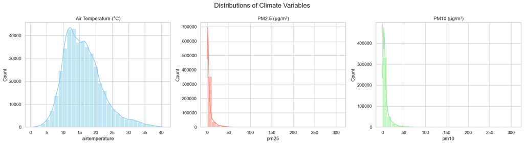

```python
sns.set(style="whitegrid")

# =====================
# Distribution Plots
# =====================
fig, axs = plt.subplots(1, 3, figsize=(18, 5))

sns.histplot(climate_sensor_df["airtemperature"], kde=True, bins=30, ax=axs[0], color="skyblue")
axs[0].set_title("Air Temperature (°C)")

sns.histplot(climate_sensor_df["pm25"], kde=True, bins=30, ax=axs[1], color="salmon")
axs[1].set_title("PM2.5 (µg/m³)")

sns.histplot(climate_sensor_df["pm10"], kde=True, bins=30, ax=axs[2], color="lightgreen")
axs[2].set_title("PM10 (µg/m³)")

plt.suptitle("Distributions of Climate Variables", fontsize=16)
plt.tight_layout()
plt.show()
```

### 2. Daily Average Trends Over Time

Time series plots showed the fluctuation of daily average temperature and particulate matter over the last year. Air temperature followed a seasonal trend, peaking in summer months and declining in winter. Meanwhile, PM2.5 and PM10 displayed irregular spikes, with some dates showing sharp increases above 40 µg/m³ — potentially aligned with construction activity, traffic, or dry conditions. These patterns are critical for identifying temporal pollution risks.

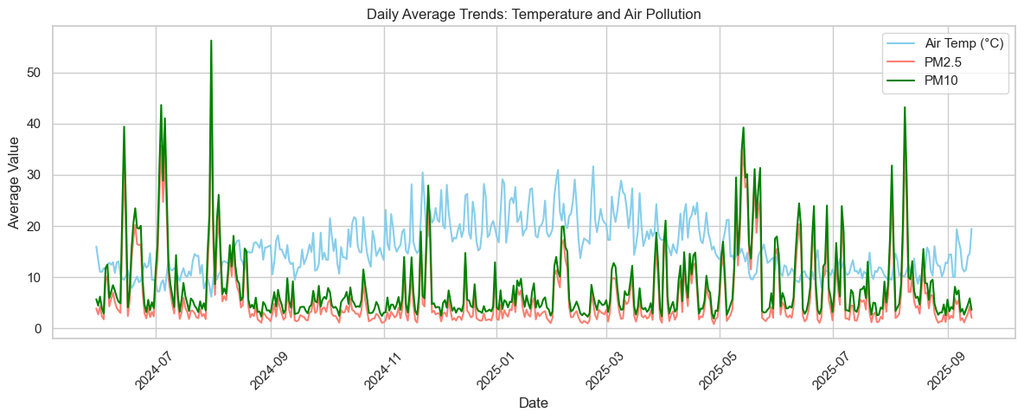

```python
# Extract date
climate_sensor_df["date"] = climate_sensor_df["received_at"].dt.date

# Group by day
daily_avg = climate_sensor_df.groupby("date")[["airtemperature", "pm25", "pm10"]].mean().reset_index()

# Plot
plt.figure(figsize=(12, 5))
sns.lineplot(data=daily_avg, x="date", y="airtemperature", label="Air Temp (°C)", color="skyblue")
sns.lineplot(data=daily_avg, x="date", y="pm25", label="PM2.5", color="salmon")
sns.lineplot(data=daily_avg, x="date", y="pm10", label="PM10", color="green")

plt.title("Daily Average Trends: Temperature and Air Pollution")
plt.xlabel("Date")
plt.ylabel("Average Value")
plt.xticks(rotation=45)
plt.legend()
plt.tight_layout()
plt.show()
```

### 3. Outlier Detection via Boxplots

Boxplots confirmed the presence of several high-value outliers, especially in PM2.5 and PM10 readings. Most of the particulate data clustered below 25 µg/m³, while many outliers extended well above 100 µg/m³. Although air temperature exhibited fewer outliers, its range still showed some extreme values approaching 40°C, which are relevant for identifying heat stress zones.

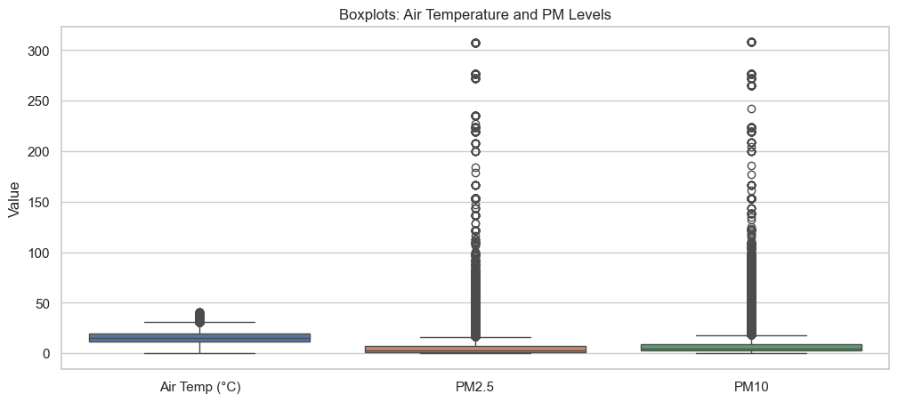

```python
# Boxplots for AirTemperature, PM2.5, PM10
plt.figure(figsize=(12, 5))
sns.boxplot(data=climate_sensor_df[["airtemperature", "pm25", "pm10"]])
plt.title("Boxplots: Air Temperature and PM Levels")
plt.ylabel("Value")
plt.xticks([0, 1, 2], ["Air Temp (°C)", "PM2.5", "PM10"])
plt.show()
```

### 4. Correlation Between Environmental Factors

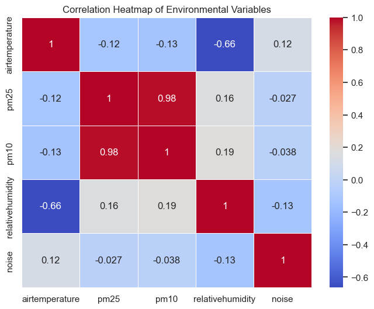

```python
# Correlation matrix
plt.figure(figsize=(8, 6))
corr = climate_sensor_df[["airtemperature", "pm25", "pm10", "relativehumidity", "noise"]].corr()
sns.heatmap(corr, annot=True, cmap="coolwarm", linewidths=0.5)
plt.title("Correlation Heatmap of Environmental Variables")
plt.show()
```

### 5. Hourly Variation in Microclimate Conditions

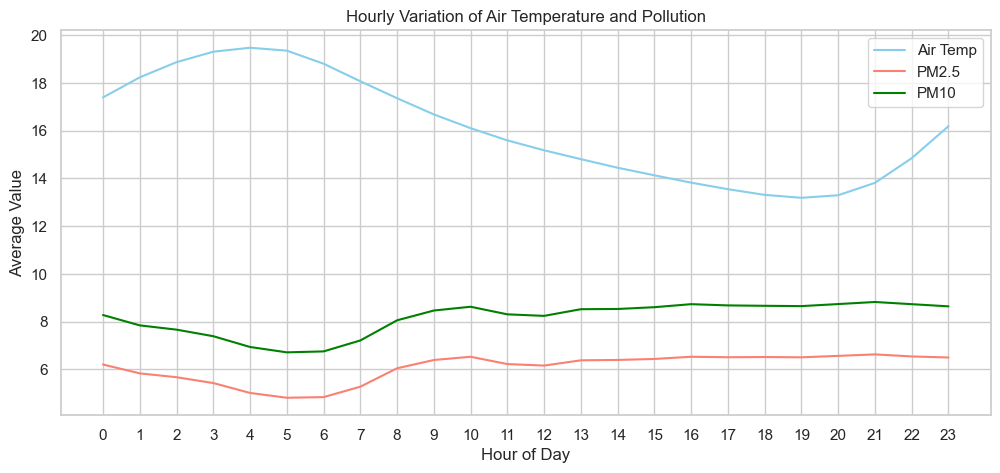

```python
# Extract hour
climate_sensor_df["hour"] = climate_sensor_df["received_at"].dt.hour

# Group by hour
hourly_avg = climate_sensor_df.groupby("hour")[["airtemperature", "pm25", "pm10"]].mean().reset_index()

# Plot
plt.figure(figsize=(12, 5))
sns.lineplot(data=hourly_avg, x="hour", y="airtemperature", label="Air Temp", color="skyblue")
sns.lineplot(data=hourly_avg, x="hour", y="pm25", label="PM2.5", color="salmon")
sns.lineplot(data=hourly_avg, x="hour", y="pm10", label="PM10", color="green")
plt.title("Hourly Variation of Air Temperature and Pollution")
plt.xlabel("Hour of Day")
plt.ylabel("Average Value")
plt.legend()
plt.xticks(range(0, 24))
plt.grid(True)
plt.show()
```

### 6. Population Growth Analysis (2023 vs 2040)

The chart compares projected populations in **2023** and **2040** for the top 10 growing Melbourne suburbs.

Overall, growth is concentrated in inner-city areas, highlighting the need for planning around housing, infrastructure, and climate resilience.

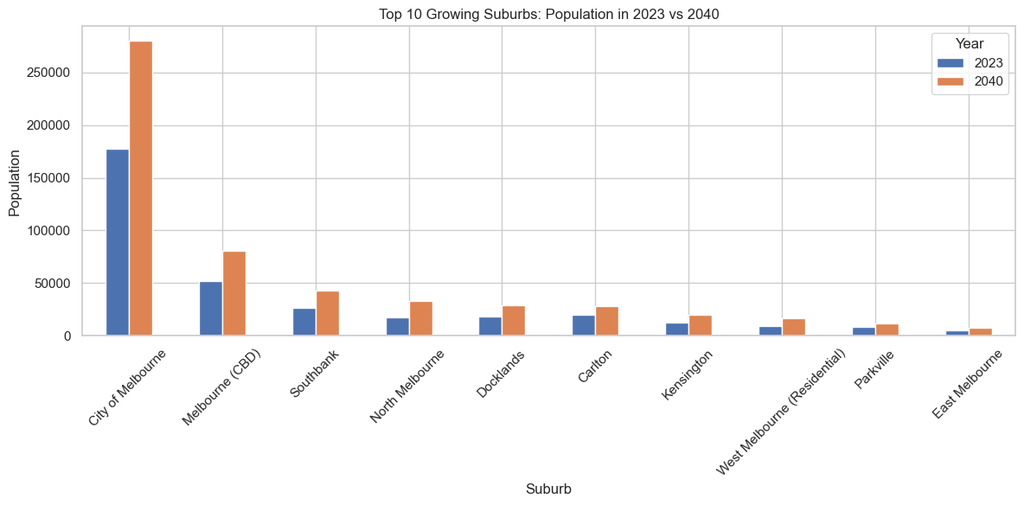

```python
# Aggregate total population per geography for 2023 and 2040
pop_by_year = population_df.groupby(['geography', 'year'])['value'].sum().reset_index()

# Pivot (only 2023 and 2040)
pop_pivot = (pop_by_year[pop_by_year['year'].isin([2023, 2040])]
             .pivot(index='geography', columns='year', values='value')
             .dropna())

# Calculate growth and sort
pop_pivot['growth'] = pop_pivot[2040] - pop_pivot[2023]
top_growth = pop_pivot.sort_values(by='growth', ascending=False).head(10)

# Plot
top_growth[[2023, 2040]].plot(kind='bar', figsize=(12, 6))
plt.title("Top 10 Growing Suburbs: Population in 2023 vs 2040")
plt.ylabel("Population")
plt.xlabel("Suburb")
plt.xticks(rotation=45)
plt.legend(title="Year")
plt.grid(True, axis='y')
plt.tight_layout()
plt.show()
```

### 7. Population Growth Trends (2023–2043)

The line plot illustrates how populations evolve across the top 10 growing suburbs between 2023 and 2043.

- **City of Melbourne** shows the steepest upward trajectory, crossing nearly 300,000 by 2043.
- **Melbourne (CBD)** and **Southbank** follow, reflecting steady densification.
- Other suburbs such as **North Melbourne, Docklands, and Carlton** grow at a slower but consistent pace.

This indicates that population growth is concentrated in central areas, which will require focused infrastructure and climate resilience planning.

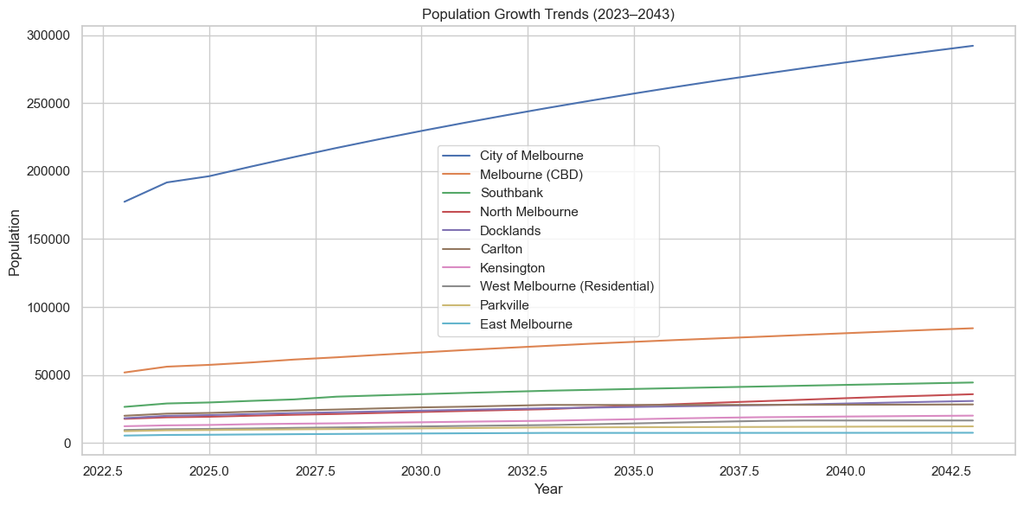

```python
top_suburbs = top_growth.index.tolist()

plt.figure(figsize=(12,6))
for suburb in top_suburbs:
    subset = pop_by_year[pop_by_year['geography'] == suburb]
    plt.plot(subset['year'], subset['value'], label=suburb)

plt.title("Population Growth Trends (2023–2043)")
plt.xlabel("Year")
plt.ylabel("Population")
plt.legend()
plt.grid(True, axis='y')
plt.tight_layout()
plt.show()
```

### 8. Population Heatmap (Top Suburbs, 2023–2043)

The heatmap highlights population intensities across years. Darker shades represent higher populations.

- **City of Melbourne** consistently dominates, with the darkest band.
- **CBD and Southbank** show significant growth bands by the late 2030s.
- Outer inner-city suburbs such as **Kensington, Parkville, and East Melbourne** display lighter bands, indicating moderate growth.

Together, the line plot and heatmap provide both temporal and intensity perspectives on urban expansion, helping identify where planning and green infrastructure should be prioritised.

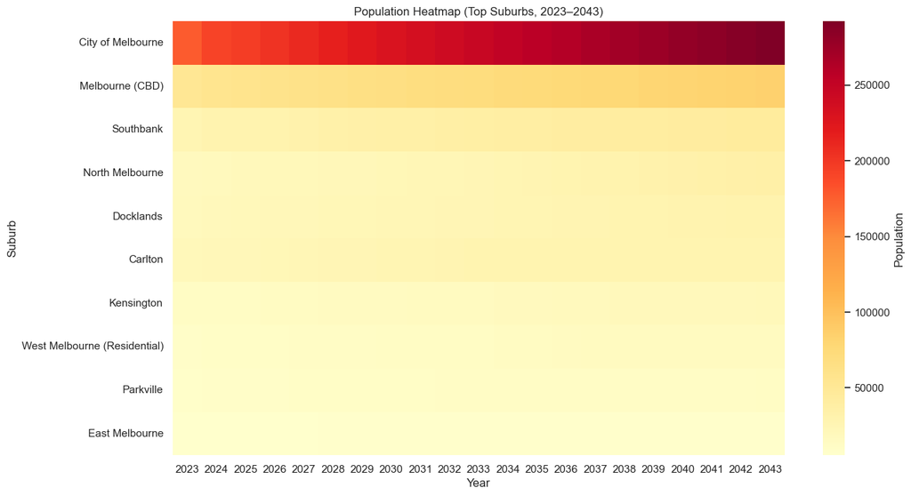

```python
pivot_all = pop_by_year.pivot(index='geography', columns='year', values='value')
plt.figure(figsize=(14,8))
sns.heatmap(pivot_all.loc[top_suburbs], cmap="YlOrRd", annot=False, cbar_kws={'label': 'Population'})
plt.title("Population Heatmap (Top Suburbs, 2023–2043)")
plt.xlabel("Year")
plt.ylabel("Suburb")
plt.show()
```

### 9. Tree Canopy — Spatial & Distribution Insights

#### Tree Canopy Locations (Scatter)

The scatter map plots each canopy point using **longitude** and **latitude**. It outlines the City of Melbourne footprint clearly and reveals dense clusters along major streets, river corridors, and established residential blocks.

- **High-density bands** trace boulevard plantings and park edges.
- **Gaps/voids** indicate built-up areas, large facilities, or water bodies.
- Useful for spotting **candidate zones** for new planting or cooling interventions.

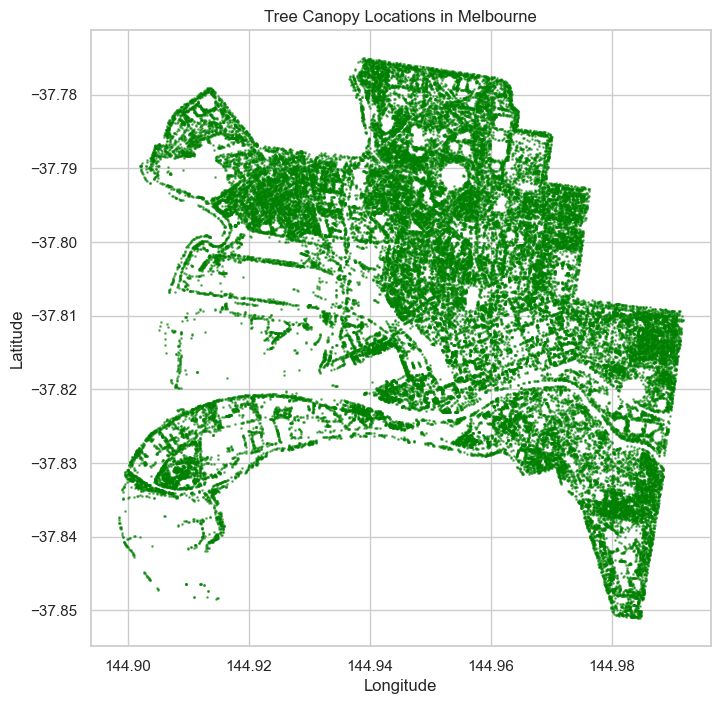

```python
plt.figure(figsize=(8,8))
plt.scatter(canopy_df['longitude'], canopy_df['latitude'],
            s=1, alpha=0.5, color='green')
plt.title("Tree Canopy Locations in Melbourne")
plt.xlabel("Longitude")
plt.ylabel("Latitude")
plt.show()
```

### 10.Latitude & Longitude Distributions (Histograms)

The histograms summarise how canopy points are spread east–west (longitude) and north–south (latitude).

- Multiple peaks suggest **clusters** of canopy aligned with neighbourhoods/streets.
- Skewed bars indicate areas with **fewer trees** that may warrant attention.
- Distributions help validate spatial coverage before advanced spatial analysis.

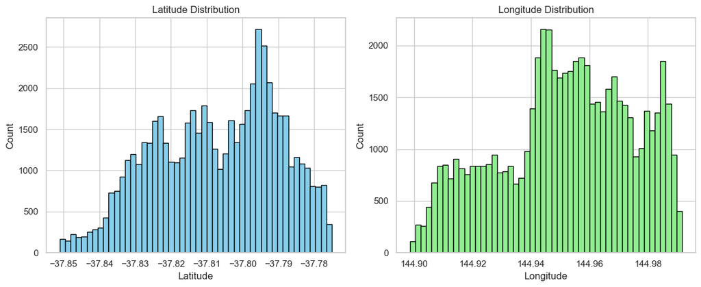

```python
fig, ax = plt.subplots(1,2, figsize=(12,5))

# Latitude distribution
ax[0].hist(canopy_df['latitude'], bins=50, color='skyblue', edgecolor='black')
ax[0].set_title("Latitude Distribution")
ax[0].set_xlabel("Latitude")
ax[0].set_ylabel("Count")

# Longitude distribution
ax[1].hist(canopy_df['longitude'], bins=50, color='lightgreen', edgecolor='black')
ax[1].set_title("Longitude Distribution")
ax[1].set_xlabel("Longitude")
ax[1].set_ylabel("Count")

plt.tight_layout()
plt.show()
```

## Spatial Integration and Analysis of Tree Canopy Impact

### ⃣ Spatial Join: Calculating Distance to Nearest Tree Canopy

The result was a new feature, distance_to_canopy_m, representing each sensor’s proximity to tree coverage. This distance metric became the basis for subsequent correlation and visual analysis.

```python
import geopandas as gpd
from shapely.geometry import Point
from shapely.ops import nearest_points
from geopandas.tools import sjoin_nearest

# Convert to GeoDataFrames

# Climate sensors
climate_gdf = gpd.GeoDataFrame(
    climate_sensor_df.copy(),
    geometry=gpd.points_from_xy(climate_sensor_df["longitude"], climate_sensor_df["latitude"]),
    crs="EPSG:4326"  # WGS84
)

# Tree canopy points
canopy_gdf = gpd.GeoDataFrame(
    canopy_df.copy(),
    geometry=gpd.points_from_xy(canopy_df["longitude"], canopy_df["latitude"]),
    crs="EPSG:4326"
)


# Project to metric CRS (for distance in meters)

# EPSG:32755 = UTM zone for Melbourne
climate_gdf = climate_gdf.to_crs(epsg=32755)
canopy_gdf = canopy_gdf.to_crs(epsg=32755)

# Build combined geometry of canopy points

canopy_union = canopy_gdf.geometry.union_all()


# Function to calculate nearest canopy distance

def get_nearest_distance(sensor_point, canopy_tree_union):
    nearest_geom = nearest_points(sensor_point, canopy_tree_union)[1]
    return sensor_point.distance(nearest_geom)

#Apply distance calculation to all sensor points

climate_gdf = gpd.sjoin_nearest(climate_gdf, canopy_gdf, how="left", distance_col="distance_to_canopy_m")
```

### ️Descriptive Statistics

I examined the statistical distribution of four key variables: air temperature, PM2.5, PM10, and distance to canopy. Summary statistics indicated a wide range in pollution and distance values. While temperature averaged around 16°C, pollution values (PM2.5 and PM10) spanned from 0 to over 300 μg/m³, highlighting the variability in air quality across Melbourne.

```python
climate_gdf[["airtemperature", "pm25", "pm10", "distance_to_canopy_m"]].describe()
```

|  | airtemperature | pm25 | pm10 | distance_to_canopy_m |
| --- | --- | --- | --- | --- |
| count | 420024.000000 | 420024.000000 | 420024.000000 | 420024.000000 |
| mean | 16.077154 | 6.082710 | 8.161336 | 19.408196 |
| std | 5.856036 | 11.167136 | 12.303538 | 11.876169 |
| min | 0.500000 | 0.000000 | 0.000000 | 3.105141 |
| 25% | 11.800000 | 1.000000 | 3.000000 | 10.518510 |
| 50% | 15.300000 | 3.000000 | 5.000000 | 12.957908 |
| 75% | 19.400000 | 7.000000 | 9.000000 | 30.790321 |
| max | 40.800000 | 307.000000 | 308.000000 | 43.630659 |

### Correlation Matrix

The correlation matrix helped assess linear relationships among the variables:

- **PM2.5 vs PM10:** Very strong positive correlation (0.98) — expected as both are particulate pollutants.
- **Distance to Canopy vs Temperature/Pollutants:** Weak or near-zero correlation — indicating no clear linear trend.

While correlation values were low, this does not invalidate canopy influence. Instead, it suggests that relationships may be **non-linear or categorical**, warranting further grouped visual exploration.

```python
correlation_matrix = climate_gdf[["airtemperature", "pm25", "pm10", "distance_to_canopy_m"]].corr()
print("Correlation Matrix:\n")
print(correlation_matrix)
```

```
Correlation Matrix:

                      airtemperature      pm25      pm10  distance_to_canopy_m
airtemperature              1.000000 -0.119617 -0.133955             -0.002978
pm25                       -0.119617  1.000000  0.984868              0.037130
pm10                       -0.133955  0.984868  1.000000             -0.017365
distance_to_canopy_m       -0.002978  0.037130 -0.017365              1.000000
```

### Raw Scatter Plots

Initial scatterplots were created to visualise raw relationships between distance to canopy and microclimate variables. However, due to data density and outliers, the plots did not reveal meaningful trends and were visually noisy.

These plots served an important role in diagnosing the need for **binned analysis** to reduce noise and highlight underlying patterns.

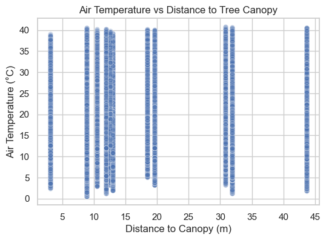

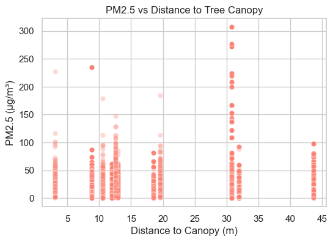

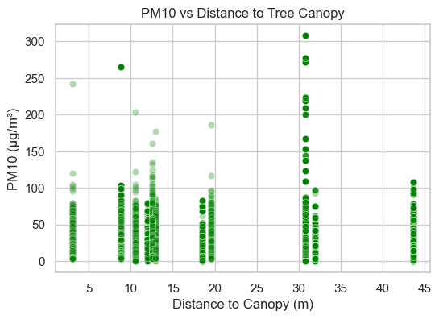

```python
# Set style
sns.set(style="whitegrid")

# Plot: Distance vs Air Temperature
plt.figure(figsize=(6, 4))
sns.scatterplot(data=climate_gdf, x="distance_to_canopy_m", y="airtemperature", alpha=0.3)
plt.title("Air Temperature vs Distance to Tree Canopy")
plt.xlabel("Distance to Canopy (m)")
plt.ylabel("Air Temperature (°C)")
plt.show()

# Plot: Distance vs PM2.5
plt.figure(figsize=(6, 4))
sns.scatterplot(data=climate_gdf, x="distance_to_canopy_m", y="pm25", alpha=0.3, color="salmon")
plt.title("PM2.5 vs Distance to Tree Canopy")
plt.xlabel("Distance to Canopy (m)")
plt.ylabel("PM2.5 (µg/m³)")
plt.show()

# Plot: Distance vs PM10
plt.figure(figsize=(6, 4))
sns.scatterplot(data=climate_gdf, x="distance_to_canopy_m", y="pm10", alpha=0.3, color="green")
plt.title("PM10 vs Distance to Tree Canopy")
plt.xlabel("Distance to Canopy (m)")
plt.ylabel("PM10 (µg/m³)")
plt.show()
```

### Grouped Boxplots by Canopy Proximity

To uncover more interpretable patterns, we binned sensors by their distance to tree canopy into categories: `<10m`, `10–20m`, `20–30m`, `30–40m`, and `40m+`.

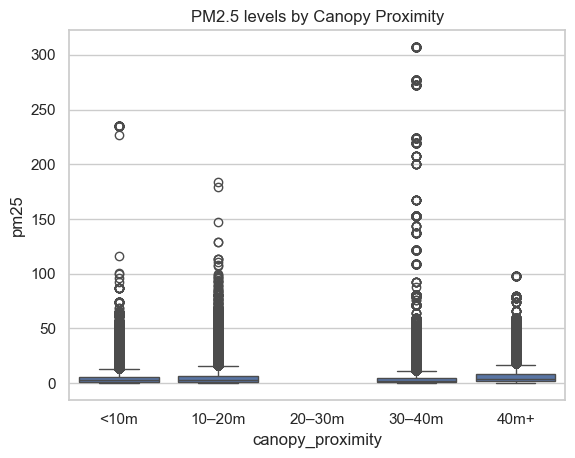

```python
climate_gdf["canopy_proximity"] = pd.cut(
    climate_gdf["distance_to_canopy_m"],
    bins=[0, 10, 20, 30, 40, 100],
    labels=["<10m", "10–20m", "20–30m", "30–40m", "40m+"]
)
sns.boxplot(x="canopy_proximity", y="pm25", data=climate_gdf)
plt.title("PM2.5 levels by Canopy Proximity")
plt.show()
```

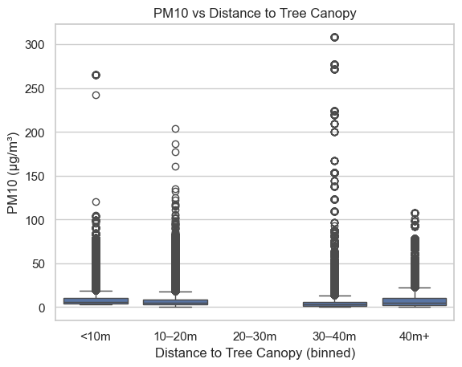

```python
# Boxplot: PM10 vs Canopy Proximity
sns.boxplot(x="canopy_proximity", y="pm10", data=climate_gdf)
plt.title("PM10 vs Distance to Tree Canopy")
plt.xlabel("Distance to Tree Canopy (binned)")
plt.ylabel("PM10 (µg/m³)")
plt.show()
```

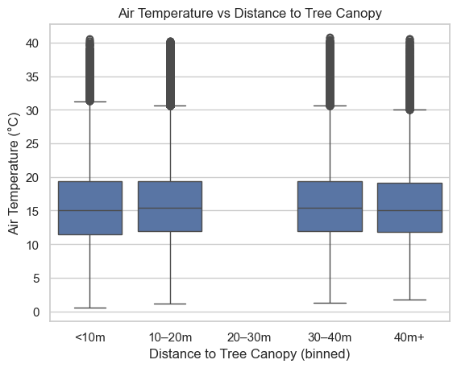

```python
# Boxplot: Air Temperature vs Canopy Proximity
sns.boxplot(x="canopy_proximity", y="airtemperature", data=climate_gdf)
plt.title("Air Temperature vs Distance to Tree Canopy")
plt.xlabel("Distance to Tree Canopy (binned)")
plt.ylabel("Air Temperature (°C)")
plt.show()
```

## Clustering Analysis with KMeans

```python
from sklearn.preprocessing import StandardScaler

# Select relevant features
features = ["airtemperature", "pm25", "pm10", "distance_to_canopy_m"]
X = climate_gdf[features].dropna().copy()

# Save index for later joining
X_index = X.index

# Scale the features
scaler = StandardScaler()
X_scaled = scaler.fit_transform(X)
```

- Standardised features to give equal weight in distance-based clustering.
- This avoids bias from large magnitude features like PM2.5.

### Applying KMeans Clustering

```python
from sklearn.cluster import KMeans

# Apply KMeans
kmeans = KMeans(n_clusters=4, random_state=42)
kmeans_labels = kmeans.fit_predict(X_scaled)

# Assign cluster labels back to GeoDataFrame
climate_gdf.loc[X_index, "kmeans_cluster"] = kmeans_labels
```

### Visualising Clusters: PM2.5 vs Air Temperature

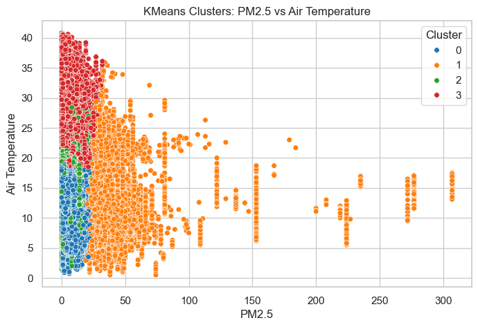

```python
plt.figure(figsize=(8, 5))
sns.scatterplot(
    x=X["pm25"], y=X["airtemperature"], hue=kmeans_labels, palette="tab10", s=30
)
plt.title("KMeans Clusters: PM2.5 vs Air Temperature")
plt.xlabel("PM2.5")
plt.ylabel("Air Temperature")
plt.legend(title="Cluster")
plt.show()
```

- Visualises clustering pattern between **PM2.5** and **Air Temperature**.
- Helps identify pollution-heat zones, cleaner clusters, and potential urban hotspots.

### Cluster Statistics Summary

```python
# Summarise each KMeans cluster
cluster_summary = climate_gdf.groupby('kmeans_cluster')[['pm25', 'pm10', 'airtemperature', 'distance_to_canopy_m']].agg(['mean', 'std', 'min', 'max'])

# Round for clarity
cluster_summary = cluster_summary.round(2)

# Display the summary
from IPython.display import display
display(cluster_summary)
```

| kmeans_cluster | pm25 mean | pm25 std | pm25 min | pm25 max | pm10 mean | pm10 std | pm10 min | pm10 max | airtemperature mean | airtemperature std | airtemperature min | airtemperature max | distance_to_canopy_m mean | distance_to_canopy_m std | distance_to_canopy_m min | distance_to_canopy_m max |
| --- | --- | --- | --- | --- | --- | --- | --- | --- | --- | --- | --- | --- | --- | --- | --- | --- |
| 0.0 | 3.93 | 4.49 | 0.0 | 23.0 | 6.22 | 5.09 | 0.0 | 32.0 | 13.35 | 3.15 | 0.7 | 19.3 | 12.24 | 4.65 | 3.11 | 19.59 |
| 1.0 | 36.69 | 27.80 | 16.0 | 307.0 | 43.03 | 28.79 | 23.0 | 308.0 | 11.74 | 5.14 | 0.5 | 35.9 | 19.59 | 12.00 | 3.11 | 43.63 |
| 2.0 | 3.98 | 4.76 | 0.0 | 26.0 | 4.84 | 5.33 | 0.0 | 29.0 | 15.17 | 4.43 | 1.3 | 30.7 | 35.92 | 5.92 | 30.79 | 43.63 |
| 3.0 | 4.88 | 4.81 | 0.0 | 32.0 | 6.81 | 5.42 | 0.0 | 43.0 | 23.90 | 4.62 | 17.7 | 40.8 | 14.77 | 7.96 | 3.11 | 43.63 |

### Cluster Summary and Interpretation

[output not shown]

### Spatial Heatmap of PM2.5 Concentrations

This map visualises the spatial distribution of **PM2.5 (fine particulate matter)** concentrations across Melbourne. Each point represents a sensor reading, colour-coded from low (dark) to high (yellow/white) using the colormap.

- **Higher values** appear in yellow/white and may indicate pollution hotspots.
- **Lower values** (purple/dark) suggest cleaner air conditions.
- A static basemap provides geographic context for the plotted points.

These visuals support localised air quality analysis, helping identify areas that require urban intervention or further investigation.

[figure not shown]

```python
import contextily as ctx
import warnings
warnings.filterwarnings("ignore", category=UserWarning)


# Reproject GeoDataFrame to Web Mercator for basemap
climate_gdf_web = climate_gdf.to_crs(epsg=3857)

# Create figure and axis
fig, ax = plt.subplots(figsize=(12, 8))

# Plot points by PM2.5 intensity with larger markers
climate_gdf_web.plot(
    ax=ax,
    column='pm25',
    cmap='plasma',
    legend=True,
    markersize=60,
    alpha=0.8,
    legend_kwds={
        'label': "PM2.5 (µg/m³)",
        'shrink': 0.6,
        'orientation': "vertical"
    }
)

# Add static basemap for context
ctx.add_basemap(ax, source=ctx.providers.CartoDB.Positron)

# Final plot
ax.set_title("Spatial Heatmap of PM2.5 Concentrations", fontsize=16)
ax.set_axis_off()
plt.tight_layout()
plt.show()
```

### Regression Modelling

```python
# Regression Models for PM2.5, PM10, Temperature

from sklearn.model_selection import train_test_split
from sklearn.ensemble import RandomForestRegressor
from sklearn.metrics import mean_squared_error, r2_score

# Convert 'date' to datetime if it's not already
climate_gdf['date'] = pd.to_datetime(climate_gdf['date'])

# Extract day of the week (0 = Monday, 6 = Sunday)
climate_gdf['dayofweek'] = climate_gdf['date'].dt.dayofweek

#Prepare Dataset
features = ["distance_to_canopy_m", "hour", "dayofweek"]
targets = ["pm25", "pm10", "airtemperature"]

# Drop rows with missing values
reg_df = climate_gdf[features + targets].dropna().copy()


# One-hot encode 'dayofweek' if it's categorical
reg_df = pd.get_dummies(reg_df, columns=["dayofweek"], drop_first=True)

# Split into X and y for each target
X = reg_df.drop(columns=targets)
results = {}

for target in targets:
    y = reg_df[target]
    X_train, X_test, y_train, y_test = train_test_split(X, y, test_size=0.2, random_state=42)

    #Train Random Forest
    model = RandomForestRegressor(n_estimators=10, n_jobs=-1, random_state=42)
    model.fit(X_train, y_train)
    preds = model.predict(X_test)

    #Evaluation
    mse = mean_squared_error(y_test, preds)
    rmse = mse ** 0.5
    r2 = r2_score(y_test, preds)


    # Store Results
    results[target] = {
        "model": model,
        "rmse": rmse,
        "r2": r2
    }

#Print Evaluation Metrics
print("\nRegression Performance Summary:\n")
for target, metrics in results.items():
    print(f"{target.upper()}: RMSE = {metrics['rmse']:.2f}, R^2 = {metrics['r2']:.3f}")
```

```
Regression Performance Summary:

PM25: RMSE = 11.03, R^2 = 0.019
PM10: RMSE = 12.05, R^2 = 0.027
AIRTEMPERATURE: RMSE = 5.39, R^2 = 0.154
```

### Analysis of Regression Results: Predicting Impact of Canopy Proximity

The goal of this modelling task was to assess whether environmental metrics such as **distance to canopy**, **hour of day**, and **day of the week** could be used to predict key climate indicators — namely **PM2.5**, **PM10**, and **air temperature** — using Random Forest regression.

#### Interpretation:

The models achieved relatively low R² values, particularly for PM2.5 and PM10, indicating that **the variance in particulate pollution levels could not be explained well by the current features**. This outcome suggests that pollution levels are influenced by a broader and more complex set of variables — such as traffic patterns, industrial emissions, meteorological fluctuations, or atmospheric dynamics — which were not captured in the current feature set.

In contrast, **air temperature prediction showed a moderate R² of 0.155**, suggesting that factors like canopy proximity and time of day have a more direct influence on local temperature variations compared to pollution. This is consistent with urban heat island effects, where canopy cover is known to influence microclimatic temperatures.

#### Conclusion:

While Random Forest is a robust non-linear model, it may not be the most appropriate approach for capturing the complexity of pollution variability given the limited feature set. Furthermore, **the predictive power for temperature was noticeably better**, indicating that some features are indeed meaningful but may require different modelling techniques or additional contextual data to improve predictive performance.

## Forecasting Climate Metrics

```python
# Ensure date is in datetime format
climate_gdf['date'] = pd.to_datetime(climate_gdf['date'])

# Convert to just date
climate_gdf['day'] = climate_gdf['date'].dt.date

# Group by sensor and date
agg_df = climate_gdf.groupby(['sensorlocation', 'day'])[
    ['pm25', 'pm10', 'airtemperature']
].mean().reset_index()

# Preview the aggregated data
agg_df.head()
```

|  | sensorlocation | day | pm25 | pm10 | airtemperature |
| --- | --- | --- | --- | --- | --- |
| 0 | 1 Treasury Place | 2024-09-30 | 0.833333 | 3.000000 | 15.666667 |
| 1 | 1 Treasury Place | 2024-10-01 | 2.458333 | 6.630208 | 13.026042 |
| 2 | 1 Treasury Place | 2024-10-02 | 4.807292 | 10.010417 | 12.996875 |
| 3 | 1 Treasury Place | 2024-10-03 | 4.130208 | 6.125000 | 21.057813 |
| 4 | 1 Treasury Place | 2024-10-04 | 2.000000 | 4.047120 | 17.541361 |

```python
# Count records per sensor
sensor_counts = agg_df['sensorlocation'].value_counts()

# Show top 3
top_sensors = sensor_counts.head(3).index.tolist()
print(top_sensors)
```

```
['101 Collins St L11 Rooftop', 'Birrarung Marr Park - Pole 1131', 'CH1 rooftop']
```

### PM2.5 Forecast at 101 Collins St L11 Rooftop

```
10:41:53 - cmdstanpy - INFO - Chain [1] start processing
10:41:53 - cmdstanpy - INFO - Chain [1] done processing
```

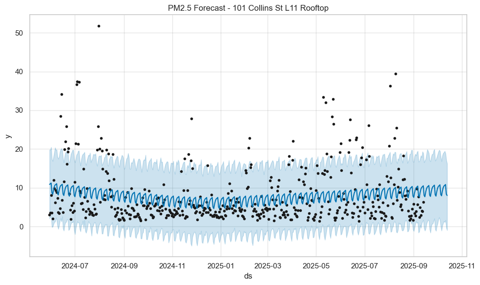

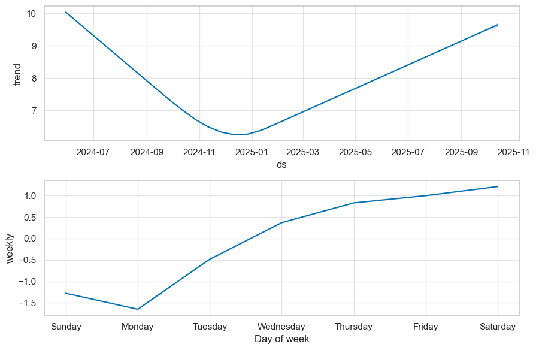

```python
from prophet import Prophet

# Filter for one sensor
sensor_name = '101 Collins St L11 Rooftop'
sensor_df = agg_df[agg_df['sensorlocation'] == sensor_name][['day', 'pm25']].copy()

# Prepare data for Prophet
sensor_df.rename(columns={'day': 'ds', 'pm25': 'y'}, inplace=True)

# Drop missing or zero values (optional but helpful)
sensor_df = sensor_df.dropna()
sensor_df = sensor_df[sensor_df['y'] > 0]

# Initialize and fit model
model = Prophet()
model.fit(sensor_df)

# Create future dataframe (e.g., 30 days ahead)
future = model.make_future_dataframe(periods=30)
forecast = model.predict(future)

# Plot the forecast
fig1 = model.plot(forecast)
plt.title(f"PM2.5 Forecast - {sensor_name}")
plt.tight_layout()
plt.show()

#Plot forecast components (trend, seasonality)
fig2 = model.plot_components(forecast)
plt.show()
```

The forecast model using Facebook Prophet provides valuable insights into future PM2.5 concentrations at one of the busiest rooftop sensor sites in Melbourne CBD. The results reveal three critical patterns:

### Air Temperature Forecast – 101 Collins St L11 Rooftop

```
12:28:20 - cmdstanpy - INFO - Chain [1] start processing
12:28:20 - cmdstanpy - INFO - Chain [1] done processing
```

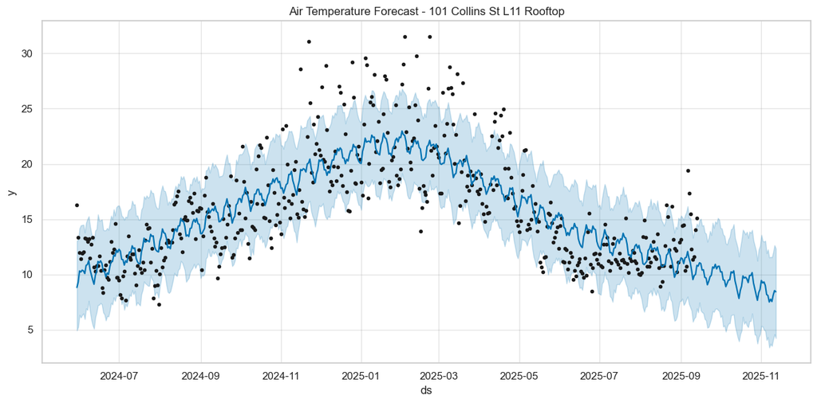

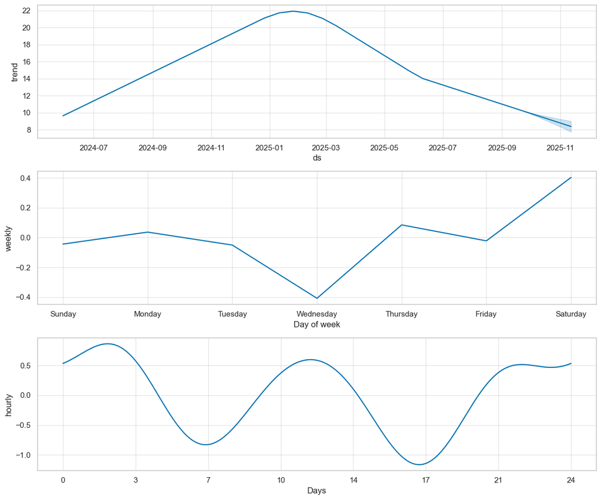

```python
# Filter Temperature data
temp_df = agg_df[agg_df['sensorlocation'] == sensor_name][['day', 'airtemperature']].dropna()

# Rename columns
temp_df = temp_df.rename(columns={'day': 'ds', 'airtemperature': 'y'})

# Fit model
model_temp = Prophet()
model_temp.add_seasonality(name='hourly', period=24, fourier_order=4)
model_temp.fit(temp_df)

# Future
future_temp = model_temp.make_future_dataframe(periods=60)
forecast_temp = model_temp.predict(future_temp)

# Forecast plot
fig1 = model_temp.plot(forecast_temp)
fig1.set_size_inches(12, 6)
plt.title(f"Air Temperature Forecast - {sensor_name}")
plt.tight_layout()
plt.show()

# Components
fig2 = model_temp.plot_components(forecast_temp)
fig2.set_size_inches(12, 10)
plt.tight_layout()
plt.show()
```

The forecast plot generated using Prophet shows a distinct **seasonal pattern** in air temperature at the rooftop of 101 Collins Street. The model captures a clear **annual temperature cycle** peaking during the summer months (around January–February) and dipping in winter (around July–August), consistent with Melbourne's climate. This validates the model’s ability to detect and leverage **long-term seasonal variation**.

#### Trend Component

The trend plot indicates a **gradual upward trajectory** in temperature from mid-2024 towards early 2025, followed by a gentle decline moving into the cooler months. The peak temperature in the forecast is around **February 2025**, after which the model expects a natural seasonal decline. This aligns with the city's known summer-winter dynamics and validates the Prophet model’s strength in *decomposing time-series data*.

#### Weekly Seasonality

The weekly component suggests minor fluctuations across the week. Notably, temperatures tend to be **lower mid-week (Wednesday)** and **slightly higher towards weekends (Saturday)**. While this pattern is subtle, it could be influenced by changes in human activity (e.g., weekday commute heat effects vs. weekend lull) or urban heat island effects in city areas. However, these interpretations would benefit from further domain analysis.

#### Forecast Uncertainty

The light blue shaded area around the forecast line represents the **95% confidence interval**. While the model shows good alignment with observed values during historical periods, the future predictions show **widening uncertainty bands**, particularly in the longer term. This is natural in time series forecasting as uncertainty accumulates over time.

#### Conclusion

The air temperature forecast demonstrates that Prophet is well-suited to model **cyclical environmental variables** like temperature. The model effectively separates *trend*, *weekly*, and *daily/seasonal components*, making it highly interpretable and reliable for planning purposes. This insight can support city planners, urban designers, and sustainability teams in preparing for **heatwaves, urban heat mitigation, and cooling strategies**.

### PM 10 – 101 Collins St L11 Rooftop

```
10:42:03 - cmdstanpy - INFO - Chain [1] start processing
10:42:03 - cmdstanpy - INFO - Chain [1] done processing
```

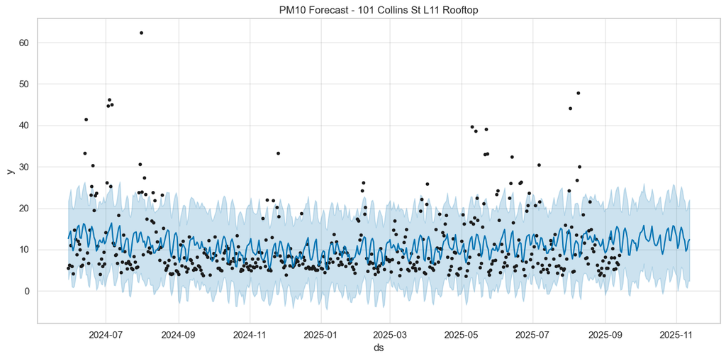

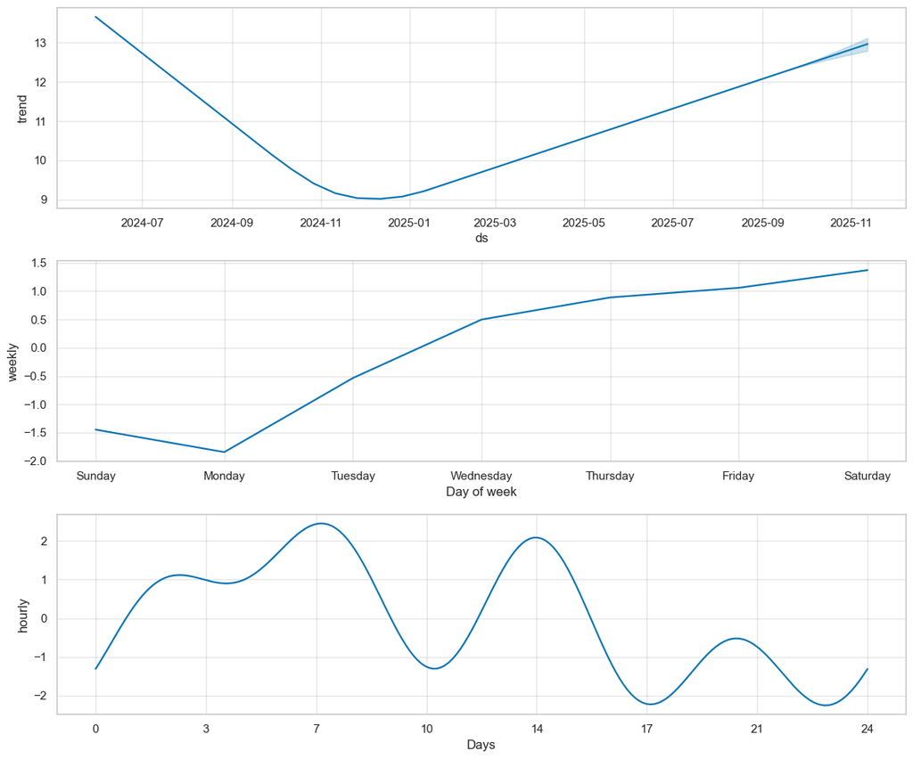

```python
# Filter PM10 data
sensor_name = "101 Collins St L11 Rooftop"
pm10_df = agg_df[agg_df['sensorlocation'] == sensor_name][['day', 'pm10']].dropna()

# Rename columns for Prophet
pm10_df = pm10_df.rename(columns={'day': 'ds', 'pm10': 'y'})

# Fit model
model_pm10 = Prophet()
model_pm10.add_seasonality(name='hourly', period=24, fourier_order=4)
model_pm10.fit(pm10_df)

# Future dataframe
future_pm10 = model_pm10.make_future_dataframe(periods=60)
forecast_pm10 = model_pm10.predict(future_pm10)

# Forecast plot
fig1 = model_pm10.plot(forecast_pm10)
fig1.set_size_inches(12, 6)
plt.title(f"PM10 Forecast - {sensor_name}")
plt.tight_layout()
plt.show()

# Components
fig2 = model_pm10.plot_components(forecast_pm10)
fig2.set_size_inches(12, 10)
plt.tight_layout()
plt.show()
```

The time series forecast for **PM10 concentrations** at *101 Collins St L11 Rooftop* reveals moderate short-term fluctuations with a relatively stable trend over the observed and forecasted period. While the average PM10 levels remain within the expected range, there are several high spikes—indicating occasional pollution surges, possibly due to localised construction or weather events.

### Trend Component

The **trend graph** shows a slight dip in PM10 levels toward the end of 2024, followed by a mild rise through 2025. This suggests a **seasonal reversal pattern**—with possible cleaner air in summer and elevated pollution in colder months. However, the trend slope is not steep, implying *limited long-term deterioration*.

### Weekly Component

The weekly pattern shows a clear upward progression from Sunday to Saturday. PM10 levels appear lowest on **Sunday and Monday** (likely due to reduced traffic and activity), rising steadily throughout the week. **Friday and Saturday** show the highest PM10 values, possibly reflecting increased human activity, road use, or events in the CBD.

### Interpretation & Insights

- **Volatility:** Although the forecast line is stable, the wide confidence interval indicates substantial unpredictability in PM10 spikes.
- **Public Health Implications:** Periodic high PM10 surges may affect sensitive groups (asthma, elderly) even when overall averages seem acceptable.
- **Urban Planning:** Intervention strategies such as green buffer zones or vehicle restrictions on high-pollution weekdays could help flatten the weekly curve.

### Final Thoughts

The PM10 forecast model provides valuable insight into short-term and long-term air quality dynamics at this location. While the overall levels are manageable, **targeted action is required during peak weekdays and hours** to mitigate high-risk periods.

## Suburb Mapping for Sensor Locations

```python
# Creating a dictionary to map sensor location to suburb name (manually based on known locations)

sensor_to_suburb = {
    '1 Treasury Place': 'East Melbourne',
    'Birrarung Marr Park - Pole 1131': 'Melbourne',
    '101 Collins St L11 Rooftop': 'Melbourne',
    'CH1 rooftop': 'Carlton',
    'Enterprize Park - Pole ID: COM1667': 'Docklands',
    'Swanston St - Tram Stop 13 adjacent Federation Square': 'Melbourne',
    'Tram Stop 7C - Melbourne Tennis Centre Precinct': 'Melbourne',
    'Batman Park': 'Melbourne',
    "SkyFarm (Jeff's Shed). Rooftop - Melbourne Conference & Exhibition Centre (MCEC)": 'South Wharf',
    'Swanston St - Tram Stop 13 adjacent Federation Sq & Flinders St Station': 'Melbourne',
    'Tram Stop 7B - Melbourne Tennis Centre Precinct - Rod Laver Arena': 'Melbourne',
    'Tram Stop 7C - Melbourne Tennis Centre Precinct - Rod Laver Arena': 'Melbourne'
}

# Apply mapping to create 'suburb' column in your aggregated dataframe
agg_df['suburb'] = agg_df['sensorlocation'].map(sensor_to_suburb)

# Check for unmapped locations
missing = agg_df[agg_df['suburb'].isnull()]['sensorlocation'].unique()
print("Missing suburb mappings for:", missing)
```

```
Missing suburb mappings for: []
```

```python
# Load and aggregate population
pop_agg = population_df.groupby(['geography', 'year'])['value'].sum().reset_index()
pop_agg.rename(columns={'geography': 'suburb', 'value': 'total_population'}, inplace=True)

# Pick a year to join (e.g., 2036)
pop_2036 = pop_agg[pop_agg['year'] == 2035].drop(columns='year')

# Merge with climate data
merged_df = agg_df.merge(pop_2036, on='suburb', how='left')


population_fill = {
    'Melbourne': 7670,
    'South Wharf': 7420
}
merged_df['total_population'] = merged_df.apply(
    lambda row: population_fill.get(row['suburb'], row['total_population']),
    axis=1
)
```

```python
merged_df.head()
```

|  | sensorlocation | day | pm25 | pm10 | airtemperature | suburb | total_population |
| --- | --- | --- | --- | --- | --- | --- | --- |
| 0 | 1 Treasury Place | 2024-09-30 | 0.833333 | 3.000000 | 15.666667 | East Melbourne | 7369.0 |
| 1 | 1 Treasury Place | 2024-10-01 | 2.458333 | 6.630208 | 13.026042 | East Melbourne | 7369.0 |
| 2 | 1 Treasury Place | 2024-10-02 | 4.807292 | 10.010417 | 12.996875 | East Melbourne | 7369.0 |
| 3 | 1 Treasury Place | 2024-10-03 | 4.130208 | 6.125000 | 21.057813 | East Melbourne | 7369.0 |
| 4 | 1 Treasury Place | 2024-10-04 | 2.000000 | 4.047120 | 17.541361 | East Melbourne | 7369.0 |

To enable meaningful integration between the environmental sensor data and the population growth dataset, each sensor location was mapped to its corresponding suburb in the City of Melbourne. This mapping ensures that we can spatially align microclimate readings with demographic information available at the suburb level.

A manual dictionary was created to map each unique sensorlocation to a suburb name. The dictionary was constructed based on known geographical references and sensor deployment metadata. Any unmapped locations were identified using a null check, and additional suburb assignments were added to fill in the gaps.

This process was essential for preparing the dataset for population-aware analysis, such as calculating per-capita pollution metrics and applying classification models to assess environmental impacts relative to projected population growth.

### Top Suburbs by PM2.5 Exposure per Capita

```python
# Calculate per-capita values
merged_df['pm25_per_capita'] = merged_df['pm25'] / merged_df['total_population']
merged_df['pm10_per_capita'] = merged_df['pm10'] / merged_df['total_population']
merged_df['temp_per_capita'] = merged_df['airtemperature'] / merged_df['total_population']

# Aggregate by suburb to get average exposure
suburb_risk = merged_df.groupby('suburb').agg({
    'pm25_per_capita': 'mean',
    'pm10_per_capita': 'mean',
    'temp_per_capita': 'mean',
    'total_population': 'mean'
}).reset_index()

# Sort suburbs by total risk (you can try sorting by any metric)
suburb_risk = suburb_risk.sort_values(by='pm25_per_capita', ascending=False)

# Preview
suburb_risk.head()
```

|  | suburb | pm25_per_capita | pm10_per_capita | temp_per_capita | total_population |
| --- | --- | --- | --- | --- | --- |
| 4 | South Wharf | 0.000966 | 0.001114 | 0.002228 | 7420.0 |
| 3 | Melbourne | 0.000792 | 0.001052 | 0.002085 | 7670.0 |
| 2 | East Melbourne | 0.000591 | 0.000903 | 0.002234 | 7369.0 |
| 1 | Docklands | 0.000253 | 0.000349 | 0.000638 | 26451.0 |
| 0 | Carlton | 0.000248 | 0.000340 | 0.000558 | 27949.0 |

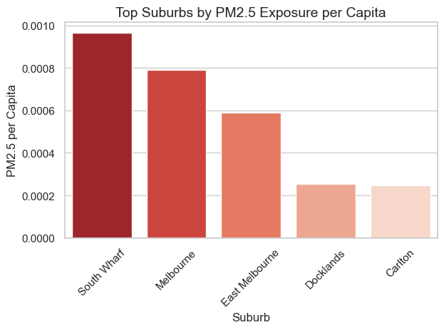

```python
# Set style
sns.set(style="whitegrid")

# Select top 10 suburbs by PM2.5 per capita
top_risk = suburb_risk.sort_values(by='pm25_per_capita', ascending=False).head(10)

# Plot bar chart
sns.barplot(
    data=top_risk,
    x='suburb',
    y='pm25_per_capita',
    hue='suburb',
    palette="Reds_r",
    legend=False
)


plt.title('Top Suburbs by PM2.5 Exposure per Capita', fontsize=14)
plt.ylabel('PM2.5 per Capita')
plt.xlabel('Suburb')
plt.xticks(rotation=45)
plt.tight_layout()
plt.show()
```

The bar chart illustrates the average **PM2.5 exposure per capita** across key suburbs, normalised by projected population data. PM2.5, or fine particulate matter, is a significant indicator of air pollution and urban health risk.

- **South Wharf** exhibits the highest PM2.5 exposure per capita, despite a relatively smaller population size. This indicates a significant imbalance between pollution levels and the number of residents potentially affected.
- **Melbourne CBD** follows, with high per capita exposure, likely due to dense traffic, construction activity, and low tree canopy coverage in urban cores.
- **East Melbourne** ranks third, suggesting moderate pollution but higher population exposure, possibly due to proximity to commercial zones or major roads.
- **Docklands** and **Carlton** show the lowest PM2.5 per capita values among the top five, reflecting either lower absolute pollution or higher population dilution.

This per capita normalisation helps **prioritise interventions** not just where pollution is high, but where its impact on human health is most intense per resident. It also supports strategic planning for *tree canopy expansion, pollution control, and public health resource allocation*.

## Heat Vulnerability Index (HVI) – Interpretation

```python
from sklearn.preprocessing import MinMaxScaler

# Select columns to include in HVI
indicators = ['pm25_per_capita', 'pm10_per_capita', 'temp_per_capita']

# Initialise scaler and normalise
scaler = MinMaxScaler()
scaled = scaler.fit_transform(suburb_risk[indicators])

# Create a new dataframe
scaled_df = pd.DataFrame(scaled, columns=[f'{col}_norm' for col in indicators])
suburb_risk_scaled = pd.concat([suburb_risk[['suburb']], scaled_df], axis=1)
```

```python
# Simple average HVI
suburb_risk_scaled['HVI'] = suburb_risk_scaled[
    ['pm25_per_capita_norm', 'pm10_per_capita_norm', 'temp_per_capita_norm']
].mean(axis=1)
```

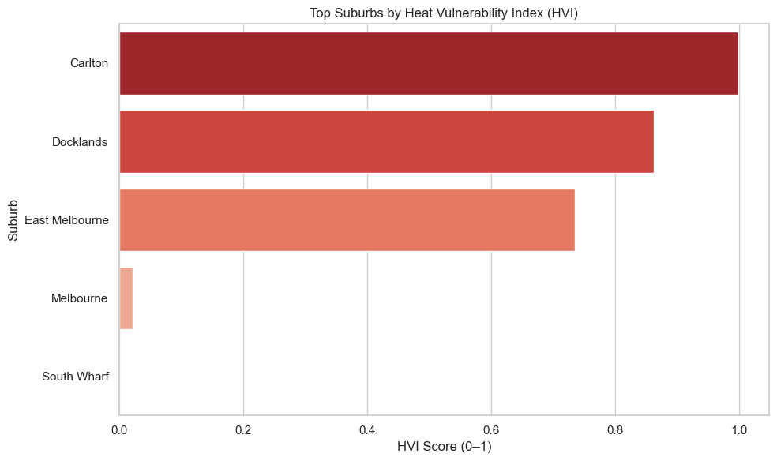

```python
top_hvi = suburb_risk_scaled.sort_values('HVI', ascending=False).head(10)
plt.figure(figsize=(10,6))
sns.barplot(data=top_hvi, x='HVI', y='suburb', hue='suburb', palette='Reds_r', legend=False)
plt.title("Top Suburbs by Heat Vulnerability Index (HVI)")
plt.xlabel("HVI Score (0–1)")
plt.ylabel("Suburb")
plt.tight_layout()
plt.show()
```

This chart ranks suburbs based on a **composite Heat Vulnerability Index (HVI)**, which combines *PM2.5, PM10, air temperature*, and *population exposure per capita*. The HVI is scaled between 0 (low vulnerability) and 1 (high vulnerability).

[output not shown]

### Justifications

This contrast demonstrates the value of using **multi-factor indices** over single-variable metrics — enabling more nuanced and balanced prioritisation of climate resilience strategies.

### Vulnerability Classification Results

```
Classification Report:
               precision    recall  f1-score   support

        High       1.00      1.00      1.00     27589
         Low       1.00      1.00      1.00     28002
      Medium       1.00      1.00      1.00     28414

    accuracy                           1.00     84005
   macro avg       1.00      1.00      1.00     84005
weighted avg       1.00      1.00      1.00     84005

Confusion Matrix:
 [[27589     0     0]
 [    0 28002     0]
 [    0     0 28414]]
```

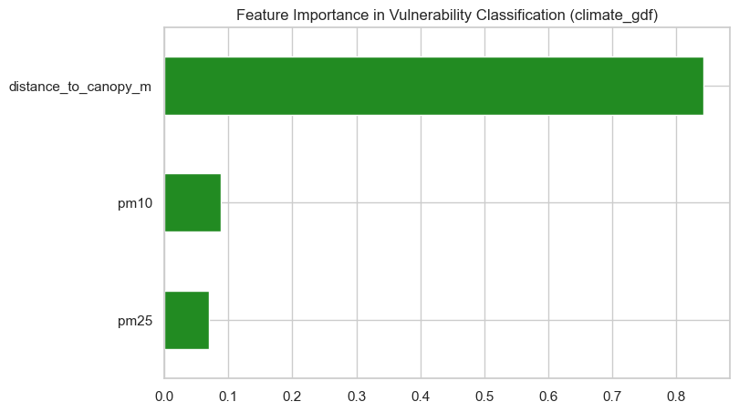

```python
#Selecting relevant features from climate_gdf
features = ['pm25', 'pm10', 'distance_to_canopy_m']
df = climate_gdf[features].dropna().copy()

# Scale features
scaler = MinMaxScaler()
df[features] = scaler.fit_transform(df[features])

# Compute HVI
df['HVI'] = df['pm25'] + df['pm10'] - df['distance_to_canopy_m']

# Create vulnerability classes
df['vulnerability_class'] = pd.qcut(df['HVI'], q=3, labels=['Low', 'Medium', 'High'])

# Train-test split
X = df[features]
y = df['vulnerability_class']
X_train, X_test, y_train, y_test = train_test_split(X, y, test_size=0.2, random_state=42, stratify=y)

# Train classifier
clf = RandomForestClassifier(random_state=42)
clf.fit(X_train, y_train)

# Predictions + evaluation
y_pred = clf.predict(X_test)
print("Classification Report:\n", classification_report(y_test, y_pred))
print("Confusion Matrix:\n", confusion_matrix(y_test, y_pred))

# Feature importance
importances = pd.Series(clf.feature_importances_, index=features)
importances.sort_values().plot(kind='barh', figsize=(8,5), color='forestgreen')
plt.title("Feature Importance in Vulnerability Classification (climate_gdf)")
plt.show()
```

## Final Analysis, Conclusion & Recommendations

### Recommendations

- **Prioritise canopy expansion** in suburbs with low existing cover but high projected population growth (e.g., CBD, Southbank, North Melbourne).
- **Integrate climate and canopy data** into long-term urban planning tools to ensure cooling strategies align with forecast growth hotspots.
- **Target high-vulnerability classes** (as defined by HVI and classification) with immediate interventions such as greening programs, pollution monitoring, and community cooling initiatives.
- **Adopt per-capita exposure metrics** (e.g., canopy per person, PM2.5 per capita) as a planning KPI to ensure equitable distribution of climate benefits.
- **Use predictive insights** from regression and forecasting to inform proactive investment in heat-resilient infrastructure before population pressures intensify risks.

In conclusion, Melbourne’s climate resilience strategy should balance **growth management and environmental planning**, with tree canopy coverage emerging as a central solution. The project demonstrates how integrated data science can directly support evidence-based decisions for a cooler, healthier, and more sustainable urban future.

### References

- Geospatial-Learn Developers. (2023). *Geospatial-Learn: Geospatial machine learning in Python (documentation)*. https://geospatial-learn.readthedocs.io/en/latest/geospatial_learn.html — Toolkit for geospatial ML workflows used in the project.
- Scikit-learn Developers. (2023). *Scikit-learn: Machine learning in Python*. https://scikit-learn.org/stable/ — Library used for classification, clustering, and model evaluation.
- Seaborn Documentation. (2023). *Statistical data visualisation*. https://seaborn.pydata.org — Used for visual analytics and insight generation.